# Exploratory Data Analysis

Uno de los pasos más importantes a la hora de modelizar es el Exploratory Data Analysis (EDA), es decir, analizar los datos disponibles para entender el problema a modelizar, la distribución de las diferentes vaiables y la relación con la variable a predecir, etc. Esto nos permitirá realizar mejores modelos, creando nuevos features que describan mejor el problema o eliminando outliers que puedan crear ruido, entre otras opciones.

## 3.1 Visualización de datos

Para realizar EDA, una de las herramientas principales es la visualización de datos. R cuenta con una librería muy potente para realizar multitud de gráficos: `ggplot2`. En la primera parte de este apartdado del curso se verá las principales funciones para crear gráficos en R.

En primer lugar, es necesario cargar el package de `ggplot2`:

```r
library(ggplot2)
```

También cargamos el dataset de precios de viviendas, ya que es el que utilizaremos en los ejemplos de los gráficos:

```r
houses_train <- read.csv("data/houses_train.csv")
```

`ggplot2` utiliza el concepto desarrollado en el libro *The Grammar of Graphics* para crear las visualizaciones de datos. En resumen, se podría decir que el concepto de *Grammar of Graphics* consiste en crear los gráficos añadiendo diversos componentes al gráfico siguiendo una “gramática”, es decir, con unas reglas respecto a que hará cada componente. Se verá más claro con un ejemplo.

### 3.1.1 Paso 1: crear la base del gráfico

En el primer paso, se crea la base del gráfico, sobre el que se añadiran los distintos elementos. Para ello, se usa la función `ggplot()`. Esta función toma dos argumentos:

- **data**: en este argumento se pasa el dataframe que contiene los datos que queremos dibujar
- **aes**: este argumento es el resultado de la función `aes()` de `ggplot2`. A la función `aes()` le pasaremos distintos argumentos que determinarán el resultado del gráfico. De momento, solamente le pasaremos el nombre de los campos que queremod dibujar en el eje x y en el eje y.

En este caso, para dibujar la relación ente la superfície de la vivienda y el precio de venta, se haría:

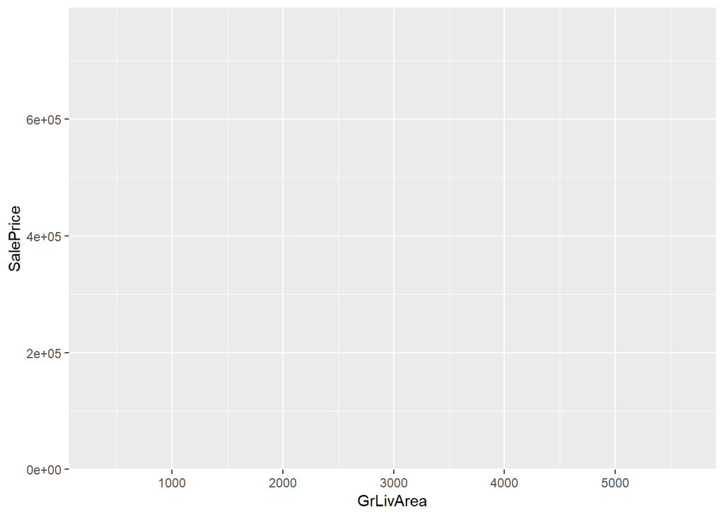

```r
ggplot(data = houses_train,
       aes(x = GrLivArea,
           y = SalePrice)) # Importante: las referencias a los ejes X e Y no se ecriben entre comillas
```

¿Qué …? No se ve nada … Bueno, era de esperar. En este primer paso, solamente hemos creado la base del gráfico, y ahora añadiremos “capas” al gráfico para poder visualizar los datos. Por comodidad, se puede tener en cuenta que la función `ggplot()` que hemos utilizado antes devuelve las caractarísticas del gráfico que hemos definido, por lo que podemos guardar este resultado en una variable para usarlos más adelante. Esto aplica a todas las funciones de `ggplot2` que utilizaremos más adelante:

```r
base_plot <- ggplot(data = houses_train,
                    aes(x = GrLivArea,
                        y = SalePrice))
```

Una vez asignado a una variable, se puede ver hacer referencia a la varaible para visualizar y modificar el gráfico:

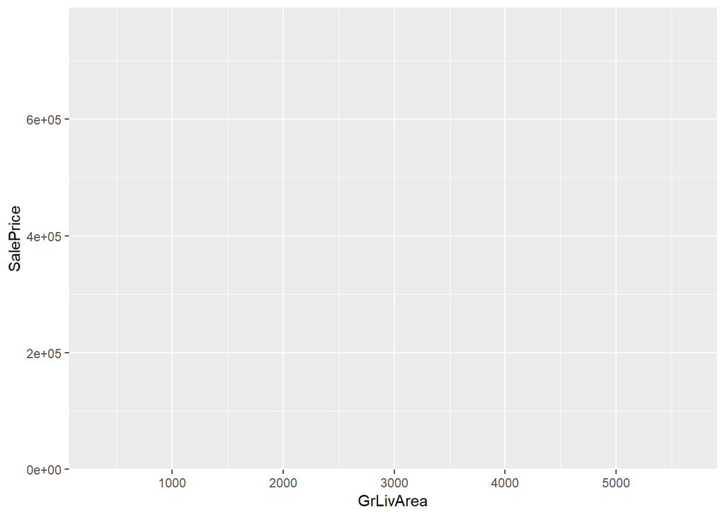

```r
base_plot
```

### 3.1.2 Paso 2: Añadir elementos al gráfico

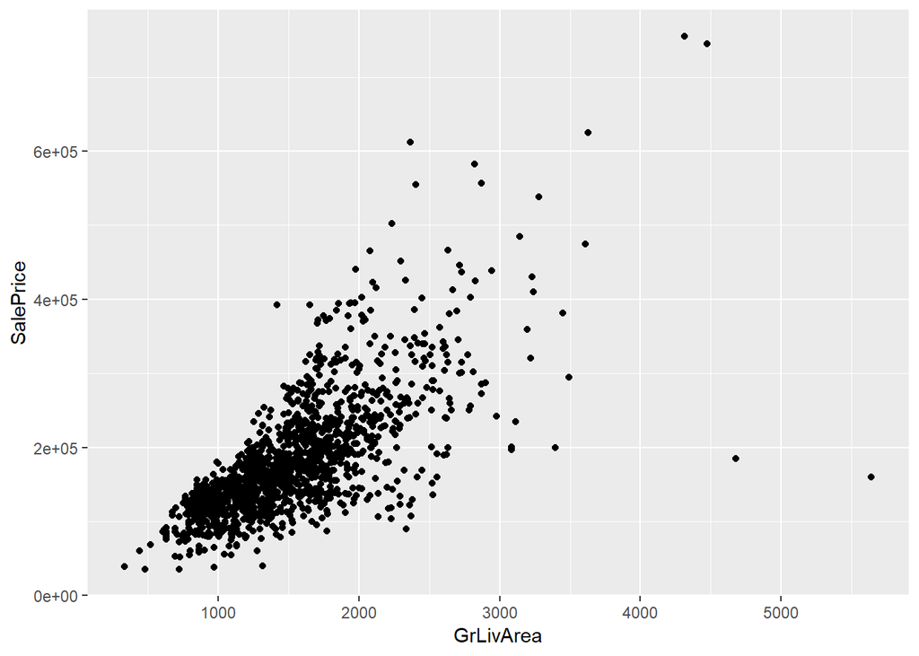

```r
scatter_plot <- base_plot + geom_point()
scatter_plot
```

Tambien se puede modificar el aspecto de la geometría que se añade al gráfico, pasando los parámetros correspondientes:

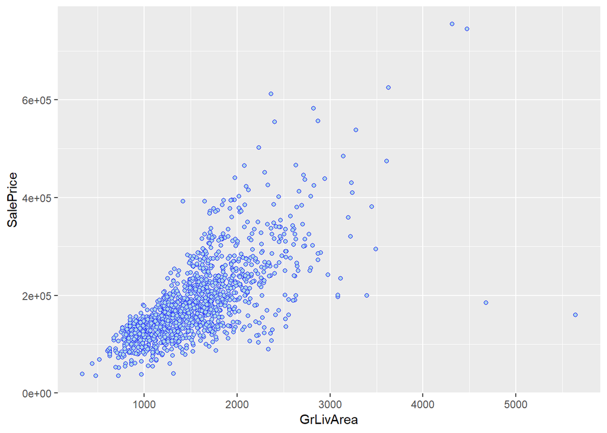

```r
scatter_plot <- base_plot + geom_point(color = "blue", fill = "lightblue", shape = 21)
scatter_plot
```

### 3.1.3 Paso 3: Últimos detalles al gráfico

Como se ha comentado anteriormente, en `gglpot2` se van añadiendo elementos al gráfico hasta obtener el resultado deseado. Siguiendo este principio, se van a añadir elementos para acabar de dar el formato deseado al gráfico anterior. En este caso, se va a añadir un título y subtítulo al gráfico, y se va a cambiar la etiqueta de los ejes x e y:

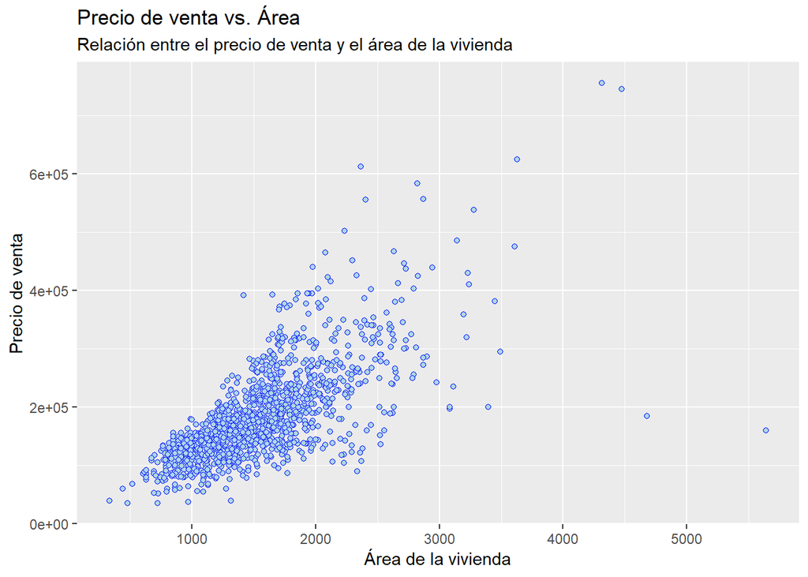

```r
title_plot <- ggtitle("Precio de venta vs. Área",
                      subtitle = "Relación entre el precio de venta y el área de la vivienda")

x_label <- xlab("Área de la vivienda")
y_label <- ylab("Precio de venta")

scatter_plot <- scatter_plot + title_plot + x_label + y_label
scatter_plot
```